[output not shown]

#### Introduction to the dataset:

The two datasets are related to red and white variants of the Portuguese “Vinho Verde” wine. We obtained the dataset from: http://archive.ics.uci.edu/ml/datasets/Wine+Quality . The website also provided the following references.1. Paulo Cortez, University of Minho, Guimar?es, Portugal, http://www3.dsi.uminho.pt/pcortez 2. A. Cerdeira, F. Almeida, T. Matos and J. Reis, Viticulture Commission of the Vinho Verde Region(CVRVV), Porto, Portugal,2009. We randomly select 1000 samples of the dataset. It contains the following variables (units are not given in the dataset description):

- fixed acidity (grams/liter)
- volatile acidity (grams/liter)
- citric acid (grams/liter)
- residual sugar (grams/liter)
- chlorides (grams/liter)
- free sulfur dioxide (milligrams/liter)
- total sulfur dioxide (milligrams/liter)
- density (grams/cubic centimeter)
- pH: acidity (below 7) or alkalinity (over 7)
- sulphates:potassium sulfate (grams/liter)
- alcohol:percentage alcohol (% volume)
- Output variable (based on sensory data): quality (score between 0 and 10)

In this report, we are interested in what impact the different qulity of red wine and white wine. We build two different models, treating quality as continuous variable and categorical variable regardingly. Here are some simple summary output of this dataset:

```
##  fixed.acidity    volatile.acidity  citric.acid     residual.sugar
##  Min.   : 4.500   Min.   :0.1000   Min.   :0.0000   Min.   : 0.700
##  1st Qu.: 6.400   1st Qu.:0.2300   1st Qu.:0.2400   1st Qu.: 1.800
##  Median : 7.000   Median :0.3000   Median :0.3000   Median : 2.900
##  Mean   : 7.178   Mean   :0.3413   Mean   :0.3157   Mean   : 5.441
##  3rd Qu.: 7.600   3rd Qu.:0.4100   3rd Qu.:0.3900   3rd Qu.: 8.400
##  Max.   :13.700   Max.   :1.3300   Max.   :1.0000   Max.   :26.050
##    chlorides       free.sulfur.dioxide total.sulfur.dioxide
##  Min.   :0.01200   Min.   :  1.00      Min.   :  7.0
##  1st Qu.:0.03700   1st Qu.: 17.00      1st Qu.: 76.0
##  Median :0.04700   Median : 29.00      Median :117.0
##  Mean   :0.05578   Mean   : 30.65      Mean   :114.9
##  3rd Qu.:0.06300   3rd Qu.: 42.00      3rd Qu.:155.0
##  Max.   :0.61100   Max.   :146.50      Max.   :344.0
##     density             pH          sulphates         alcohol
##  Min.   :0.9871   Min.   :2.830   Min.   :0.2500   Min.   : 8.00
##  1st Qu.:0.9922   1st Qu.:3.100   1st Qu.:0.4300   1st Qu.: 9.50
##  Median :0.9950   Median :3.210   Median :0.5000   Median :10.25
##  Mean   :0.9947   Mean   :3.215   Mean   :0.5245   Mean   :10.47
##  3rd Qu.:0.9970   3rd Qu.:3.320   3rd Qu.:0.6000   3rd Qu.:11.30
##  Max.   :1.0030   Max.   :3.850   Max.   :1.3600   Max.   :14.05
##     quality         type
##  Min.   :3.000   red  :243
##  1st Qu.:5.000   white:757
##  Median :6.000
##  Mean   :5.803
##  3rd Qu.:6.000
##  Max.   :8.000
```

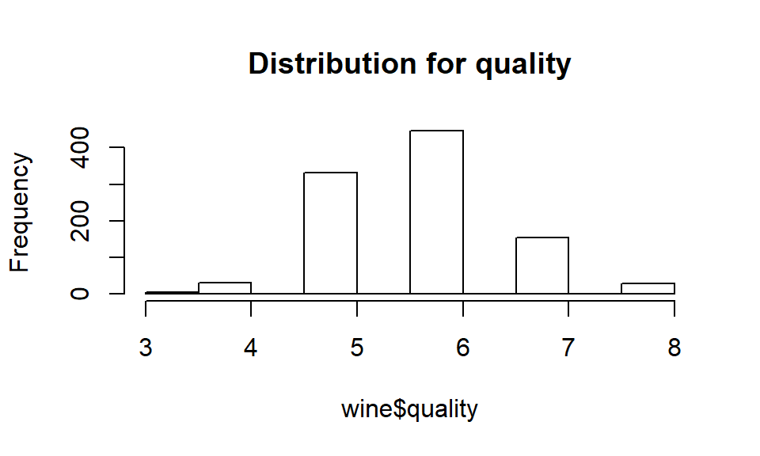

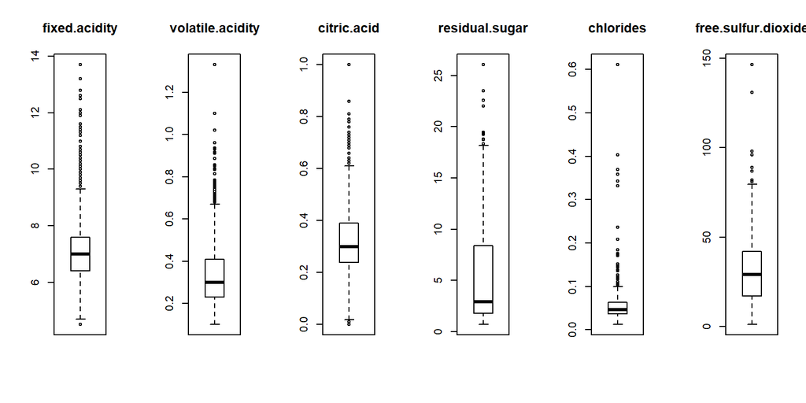

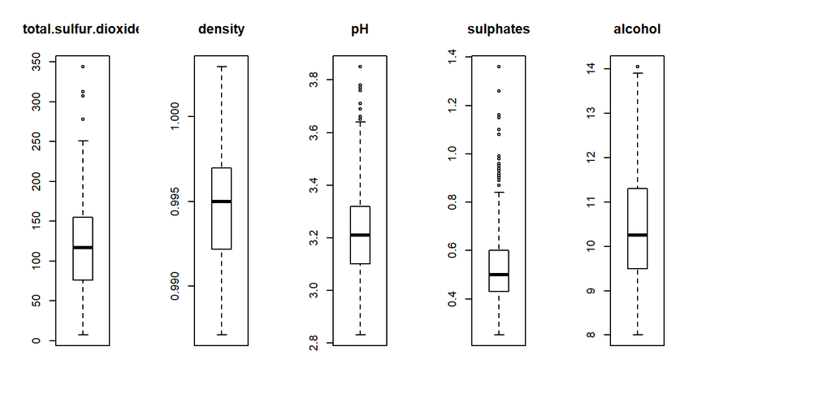

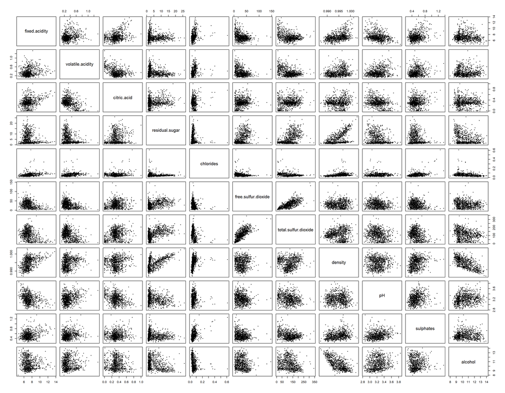

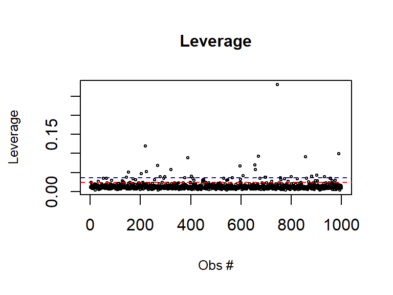

```r
which(h>thresh3)
```

```
## 145 153 204 220 224 269 279 298 321 388 402 597 608 655 658 669 696 699
## 145 153 204 220 224 269 279 298 321 388 402 597 608 655 658 669 696 699
## 745 800 856 881 902 932 989
## 745 800 856 881 902 932 989
```

#### Check Collinearity and Re-Scaling X’s

#### Assumption Check and Potential Outlier

#### Regression Model treating Quality as continuous Variable and Model Selection

#### Logistic Model treating Quality as Categorical Variable and Model Selection